# Homework06-Zeynep

Zeynep Senveli

10/19/2017

# Reading in the Kamilar and Cooper dataset:

```r
library(curl)
```

```r
library(ggplot2)
f <- curl("https://raw.githubusercontent.com/fuzzyatelin/fuzzyatelin.github.io/master/AN597_Fall17/KamilarAndCooperData.csv")
d <- read.csv(f, header = TRUE, sep = ",", stringsAsFactors = FALSE)
head(d)
```

```
##               Scientific_Name          Family          Genus      Species
## 1 Allenopithecus_nigroviridis Cercopithecidae Allenopithecus nigroviridis
## 2         Allocebus_trichotis Cercopithecidae      Allocebus    trichotis
## 3           Alouatta_belzebul        Atelidae       Alouatta     belzebul
## 4             Alouatta_caraya        Atelidae       Alouatta       caraya
## 5            Alouatta_guariba        Atelidae       Alouatta      guariba
## 6           Alouatta_palliata        Atelidae       Alouatta     palliata
##   Brain_Size_Species_Mean Brain_Size_Female_Mean   Brain_size_Ref
## 1                   58.02                  53.70 Isler et al 2008
## 2                      NA                     NA
## 3                   52.84                  51.19 Isler et al 2008
## 4                   52.63                  47.80 Isler et al 2008
## 5                   51.70                  49.08 Isler et al 2008
## 6                   49.88                  48.04 Isler et al 2008
##   Body_mass_male_mean Body_mass_female_mean Mass_Dimorphism
```

[output cut: 69 more lines]

```r
attach(d)
```

# The regression:

```r
attach(d)
regression <- lm(d$MaxLongevity_m ~ d$Brain_Size_Species_Mean, data = d)
regression
```

```
##
## Call:
## lm(formula = d$MaxLongevity_m ~ d$Brain_Size_Species_Mean, data = d)
##
## Coefficients:
##               (Intercept)  d$Brain_Size_Species_Mean
##                   248.952                      1.218
```

```r
summary(regression)
```

```
##
## Call:
## lm(formula = d$MaxLongevity_m ~ d$Brain_Size_Species_Mean, data = d)
##
## Residuals:
##     Min      1Q  Median      3Q     Max
## -198.27  -61.92  -17.78   56.16  331.36
##
## Coefficients:
##                           Estimate Std. Error t value Pr(>|t|)
## (Intercept)               248.9523    11.1111   22.41   <2e-16 ***
## d$Brain_Size_Species_Mean   1.2180     0.1101   11.06   <2e-16 ***
## ---
## Signif. codes:  0 '***' 0.001 '**' 0.01 '*' 0.05 '.' 0.1 ' ' 1
##
## Residual standard error: 90.91 on 126 degrees of freedom
##   (85 observations deleted due to missingness)
## Multiple R-squared:  0.4928, Adjusted R-squared:  0.4887
## F-statistic: 122.4 on 1 and 126 DF,  p-value: < 2.2e-16
```

# Writing up the regression equation extracting it from the coefficient matrix in the summary to later append on the graph:

```r
attach(d)
summary(regression)
```

```
##
## Call:
## lm(formula = d$MaxLongevity_m ~ d$Brain_Size_Species_Mean, data = d)
##
## Residuals:
##     Min      1Q  Median      3Q     Max
## -198.27  -61.92  -17.78   56.16  331.36
##
## Coefficients:
##                           Estimate Std. Error t value Pr(>|t|)
## (Intercept)               248.9523    11.1111   22.41   <2e-16 ***
## d$Brain_Size_Species_Mean   1.2180     0.1101   11.06   <2e-16 ***
## ---
## Signif. codes:  0 '***' 0.001 '**' 0.01 '*' 0.05 '.' 0.1 ' ' 1
##
## Residual standard error: 90.91 on 126 degrees of freedom
##   (85 observations deleted due to missingness)
## Multiple R-squared:  0.4928, Adjusted R-squared:  0.4887
## F-statistic: 122.4 on 1 and 126 DF,  p-value: < 2.2e-16
```

```r
intercept <- summary(regression)$coefficients[1,1]
slope <- summary(regression)$coefficients[2,1]
error <- summary(regression)$coefficients[1,2]
x <- NULL
equation <- intercept + slope*x + error
```

# Plotting the regression equation:

```r
attach(d)
```

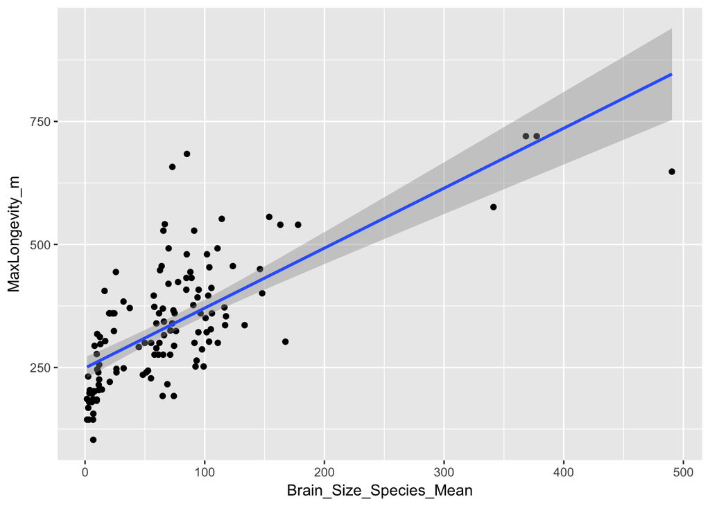

```r
g <- ggplot(data = d, aes(x = Brain_Size_Species_Mean, y = MaxLongevity_m))
g <- g + geom_point()
g <- g + geom_smooth(method = "lm", formula = y ~ x)
g
```

# Our preditor variable is brain size and our output variable is longevity. For every 1 unit change in brain size, there will be a 1.22 increase in longevity. Looking at my F-statistic to see if I can reject/fail to reject my null hypothesis, and my results are F(1,126)=122.4, p < 2.2e-16, which allows me to very certainly reject null hypothesis because my p value is very significant.

# 90% Confidence Interval:

```r
CI <- confint(regression, level = 0.90)
CI
```

```
##                                  5 %      95 %
## (Intercept)               230.540738 267.36379
## d$Brain_Size_Species_Mean   1.035571   1.40041
```

```r
summary(CI)
```

```
##       5 %               95 %
##  Min.   :  1.036   Min.   :  1.40
##  1st Qu.: 58.412   1st Qu.: 67.89
##  Median :115.788   Median :134.38
##  Mean   :115.788   Mean   :134.38
##  3rd Qu.:173.164   3rd Qu.:200.87
##  Max.   :230.541   Max.   :267.36
```

# So my 90% CI tells me that for every 1 unit of increase in brain size, the range of the increase in longevity should fall between 1.03 and 1.40.

# My point estimate for 800mg:

```r
p_estimate = intercept + slope*800 + error
p_estimate
```

```
## [1] 1234.456
```

# Calculating residuals:

```r
m <- lm(data = d, d$MaxLongevity_m ~ d$Brain_Size_Species_Mean)
h_hat <- predict(m, newdata = data.frame(Brain_Size_Species_Mean = d$Brain_Size_Species_Mean))
df <- data.frame(cbind(d$Brain_Size_Species_Mean, d$MaxLongevity_m, h_hat))
names(df) <- c("Brain Size", "Longevity", "yhat")
head(df)
```

```
##   Brain Size Longevity     yhat
## 1      58.02     276.0 319.6201
## 2         NA        NA       NA
## 3      52.84        NA 313.3109
## 4      52.63     243.6 313.0551
## 5      51.70        NA 311.9224
## 6      49.88     300.0 309.7056
```

# Setting the prediction interval:

```r
pi <- predict(m, newdata = data.frame(Brain_Size_Species_Mean = d$Brain_Size_Species_Mean), interval = "prediction",
    level = 0.90)
head(pi)
```

```
##        fit      lwr      upr
## 1 319.6201 168.3750 470.8651
## 2       NA       NA       NA
## 3 313.3109 162.0496 464.5722
## 4 313.0551 161.7930 464.3172
## 5 311.9224 160.6567 463.1880
## 6 309.7056 158.4324 460.9789
```

# The same process now for log values, starting with assigning the log values to new variables:

```r
log_brainsize <- log(d$Brain_Size_Species_Mean)
log_brainsize
```

```
##   [1] 4.0607878        NA 3.9672685 3.9632863 3.9454578 3.9096201 3.9343714
##   [8] 4.0113252 3.0286834        NA 2.7911651        NA        NA 2.8243507
##  [15]        NA 1.9344158 4.7623449 4.7383015 4.6548171 4.6429476 2.2884862
##  [22] 2.0731719 4.7597779 4.7066432 4.3307333 4.2307676        NA        NA
##  [29]        NA        NA        NA 2.4362415 2.0731719        NA        NA
##  [36]        NA 1.9796212        NA 1.9906103 1.4279160 4.1812865 4.1991549
##  [43] 4.2895001 4.2462069 4.1910174 4.7572902 4.5958267 4.6633448 4.5505028
##  [50] 4.2499228 4.0873199 4.0498701 4.1783793 4.1369250 4.1805223 4.1881384
##  [57] 4.3067642 4.2673170 4.1245504 4.1892001 4.2645092 4.0087867 4.0869842
##  [64]        NA        NA 4.1182238 1.7595806 0.9555114 3.8780525 4.1743873
##  [71] 4.1364457 4.1730017 4.3528553 4.3093215 4.3017652 4.3161539 4.2914179
##  [78] 3.8033236 4.5822086 3.0657246 3.0955776        NA 3.0277153 3.2492110
##  [85] 3.1990812 3.0041964 3.2669038 3.2347492        NA 1.7101878 1.5303947
##  [92] 1.3110319 1.3762440 0.9745596 1.2556160 6.1969939 6.1952418        NA
##  [99] 2.6454653 2.6246686        NA 4.5126162 4.4772232 4.6236975        NA
```

[output cut: 16 more lines]

```r
log_longevity <- log(d$MaxLongevity_m)
log_longevity
```

```
##   [1] 5.620401       NA       NA 5.495528       NA 5.703782 5.480639
##   [8] 5.703782 5.886104       NA 6.005367       NA       NA 5.715711
##  [15] 5.580484 5.049856 5.817111 6.313548 5.791793 6.117216       NA
##  [22]       NA       NA 6.198479 5.780744 5.375278 5.703782       NA
##  [29] 5.715711       NA       NA 5.369707 5.306286       NA 5.352806
##  [36] 5.192957 5.306286 5.480639 5.219274 5.199601 6.269096 6.293789
##  [43] 6.488597 6.198479       NA 5.918894 5.529429 5.886104 5.773309
##  [50]       NA 5.827768 5.981414 5.620401 6.103900       NA 5.838313
##  [57] 5.257495 5.784440 5.886104 5.754476 5.620401 5.429346 5.667118
##  [64] 5.743003       NA       NA 5.192957 5.445012 5.460436 5.912421
##  [71]       NA       NA 6.048790 5.683580 5.902633       NA       NA
##  [78] 5.675383 5.658785       NA       NA       NA 5.397257 6.095825
##  [85] 5.886104 5.886104 5.480639       NA       NA 5.192957       NA
##  [92] 5.288267 5.318120 5.123964       NA       NA 6.473891       NA
##  [99] 5.323985       NA 4.969813 6.269096 6.095825 6.173786 6.291569
```

[output cut: 16 more lines]

# The regression equation for log values:

```r
log_regression <- lm(log(d$MaxLongevity_m) ~ log(d$Brain_Size_Species_Mean), data = d)
log_regression
```

```
##
## Call:
## lm(formula = log(d$MaxLongevity_m) ~ log(d$Brain_Size_Species_Mean),
##     data = d)
##
## Coefficients:
##                    (Intercept)  log(d$Brain_Size_Species_Mean)
##                         4.8790                          0.2341
```

```r
summary(log_regression)
```

```
##
## Call:
## lm(formula = log(d$MaxLongevity_m) ~ log(d$Brain_Size_Species_Mean),
##     data = d)
##
## Residuals:
##     Min      1Q  Median      3Q     Max
## -0.6955 -0.1750 -0.0097  0.1788  0.6084
##
## Coefficients:
##                                Estimate Std. Error t value Pr(>|t|)
## (Intercept)                     4.87895    0.06907   70.63   <2e-16 ***
## log(d$Brain_Size_Species_Mean)  0.23415    0.01781   13.15   <2e-16 ***
## ---
## Signif. codes:  0 '***' 0.001 '**' 0.01 '*' 0.05 '.' 0.1 ' ' 1
##
## Residual standard error: 0.2485 on 126 degrees of freedom
##   (85 observations deleted due to missingness)
## Multiple R-squared:  0.5784, Adjusted R-squared:  0.5751
## F-statistic: 172.9 on 1 and 126 DF,  p-value: < 2.2e-16
```

# Plotting the graph for log values:

```r
attach(d)
```

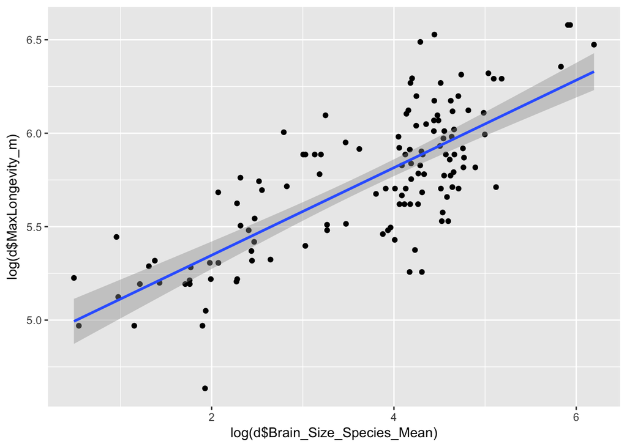

```r
g_log <- ggplot(data = d, aes(x = log(d$Brain_Size_Species_Mean), y = log(d$MaxLongevity_m)))
g_log <- g_log + geom_point()
g_log <- g_log + geom_smooth(method = "lm", formula = y ~ x)
g_log
```

```r
CI_log <- confint(regression, level = 0.90)
CI_log
```

```
##                                  5 %      95 %
## (Intercept)               230.540738 267.36379
## d$Brain_Size_Species_Mean   1.035571   1.40041
```

```r
summary(CI_log)
```

```
##       5 %               95 %
##  Min.   :  1.036   Min.   :  1.40
##  1st Qu.: 58.412   1st Qu.: 67.89
##  Median :115.788   Median :134.38
##  Mean   :115.788   Mean   :134.38
##  3rd Qu.:173.164   3rd Qu.:200.87
##  Max.   :230.541   Max.   :267.36
```

# Our preditor variable is the log of brain size and our output variable is the log of longevity. For every 1 unit change in log of brain size, there will be a 0.23 increase in longevity. Looking at my F-statistic to see if I can reject/fail to reject my null hypothesis, and my results are F(1,126)=172.9, p < 2.2e-16, which allows me to very certainly reject null hypothesis because my p value is very significant.

# Looking at the two models, the log one is better because the coefficient of determination in the log model is 57% while it is 49% for the first model. This means that the log values of the brain size mean accounts for a greater proportion of the variance we see in the log values of longevity.